# Part II - IBM HR: Employee Attrition Analysis

## by Trevlyin M.I Muzinda

## Investigation Overview

The goal of this analysis is to attain the attrition rate and the possible factors which may give rise or decrease to this rate. We will be focusing on MaritalStaus, JobInvolvement, OverTime, WorkLifeBalance, EnvironmentSatisfaction, and BusinessTravel.

## Dataset Overview

The HR Employee Attrition dataset is a fictional dataset consisting of 1470 employees, pulled together by IBM specialists and made available through the [data.world](https://data.world/aaizemberg/hr-employee-attrition) platform. It contains information on employees demographic and other situational standings with attrition status. Some of the ordinal categorical variables in the dataset was given a rating attained from the same author via [Kaggle](https://www.kaggle.com/datasets/pavansubhasht/ibm-hr-analytics-attrition-dataset)

## Employee Attrition Rate

The attrition rate, the average of employees who became part of the attriton sample, for the 1470 employees is 16% which is an occupancy of 237 employees.

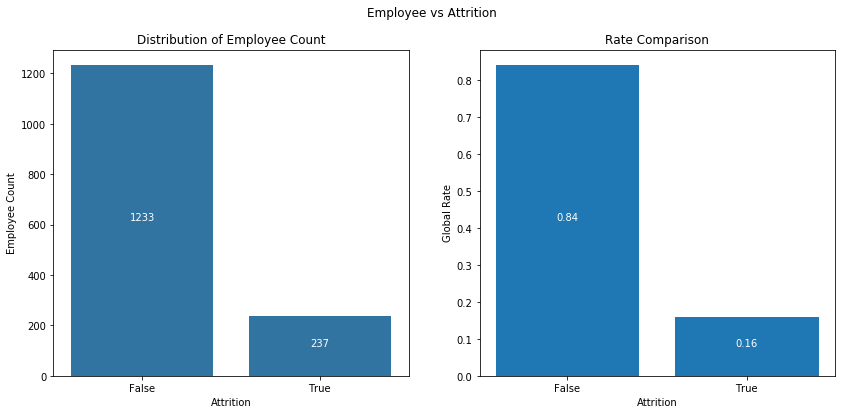

## Marital Status vs Attrition

Within the dataset the dominant or high risk attrition group are Single Employees which are 32% of Employees. Among the Single Employees they highlighted a large attrition group mean of **25.53%**,*~205% and ~253%* increase compared to its counterparts Married and Divorced respectively. Hence, keeping in mind the global rate being 16%, the Single employee group have an attrition risk of **~1.60** *(25.53/16)* resulting in high risk for attrition. The latter Married and Divorced employees are at low risk of attrition as their risks are lower than 1.

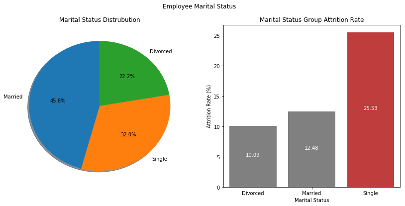

## EnvironmentSatisfaction vs Attrition Rate

Environment satisfaction presents a negative correlation as seen on the figure to the right, the higher the satisfaction rating the lower the risk for employees to be part of the attrition sample. Employees who rated a low satisfaction for their environment are seen to have an attrition rate of **25.35%**, a 2 times increase compared to other ratings, also resulting in high attrition risk.

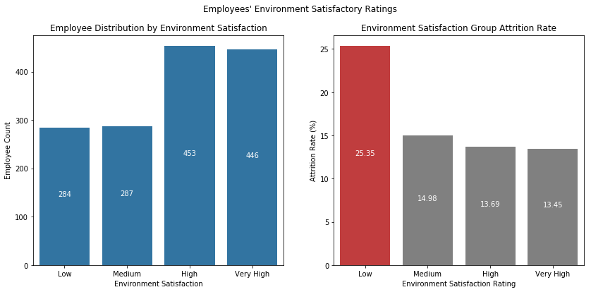

## BusinessTravel vs Attrition Rate

1043(**71%**) employees travel rarely, 277(**18.8%**) of them travel frequently and only 150(**10.2%**) of them do not travel for business in their current positions. Among the 18.8% who travel frequently, seems to have a positive effect/correlation on the average attrition rate for the group. As seen from Non-Travel employees have an 8% chance to leave the company which is 2 times less likely than any other employees. Employees who Travel_Rarely have a 1.87 times increase of being part of the attrition sample compared to its first counterpart. An attrition mean which resulted to be the highest in the group with **24.91%** and qualifies as high risk, are employees with an approximate of 156% increased likelihood to be part of the attrition sample Travel_Frequently than the rest.

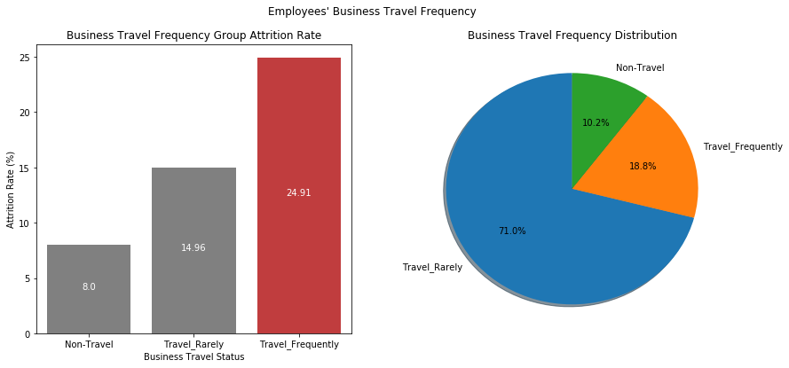

## OverTime vs Attrition Rate

Among the 416 employees who work over-time, the group has significantly a higher attrition rate of **30.53%** compared to the **10.44%** of the employees who do not. Hence employees who tend to work past standard hours have a higher attrition risk than those who do not.

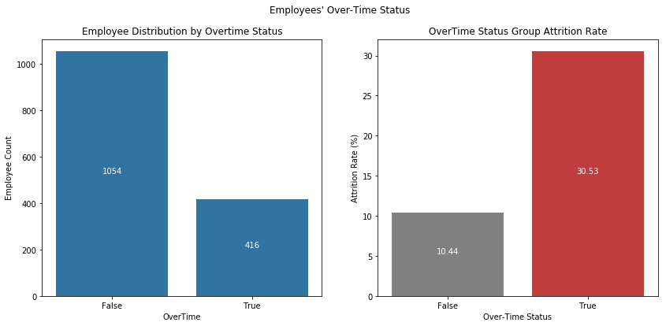

## Job Involvement vs Attrition Rate

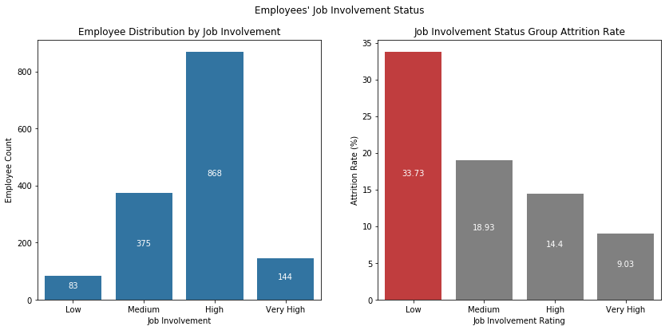

## Work-Life Balance vs Attrition Rate

The WorkLifeBalance vs Attrition mean resembles an unusual distribution where going up in work-life balance ratings the mean was decreasing, till we got to the Best rating where a sudden raise occured surpassing the Good rating by 0.79%. The Bad rating had an attrition rate of **31.25%** employees within this group.

[figure not shown]

## Improving Work-Life Balance

After isolating features to find factors for the unusual distribution of work-life balance ratings to attrition rate, the 'best' work-life balance large attrition rates for the employees who are **frequent travellers and have low environment satisfaction**, raised suspicion on if they were the cause. Filtering the criteria out and replotting the `WorkLifeBalance` vs `Attrition` resolved the distribution into a negatively correlated outcome and shows that cutting down amount of travel and improving their work environment will reduce attrition rate as follows:

Hence it suggests that improving the working environment and giving employees less business travel will significantly lower the global attrition rate from 16% to 11.98% which is ~4% decrease. A demographic to focus on which gives almost twice the attrition risk are Single Employees.

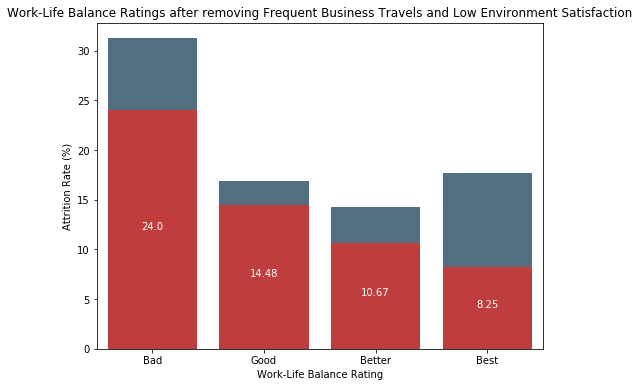